# Introduction to advance plotting and maps with R

Olalla Díaz-Yáñez

4/5/2018

# Intro

In the previous session we saw how to plot a simple graph using the function plot() and how using [graphical parameters](https://www.statmethods.net/advgraphs/parameters.html) we can improve our graph. With R you can also plot maps and even make complex spatial analysis. In this session we will looked at how to plot maps but if you are over excited and want to directly move to the second part I recomend the book [Spatial Point Patterns: Methodology and Applications with R](https://www.crcpress.com/Spatial-Point-Patterns-Methodology-and-Applications-with-R/Baddeley-Rubak-Turner/p/book/9781482210200).

There are several R packages to plot, work with maps and make nice graphs and visualizations and packages that would help you with spatial analysis and can substitute (if you want) traditional GIS software. Some of these packages are ggplot2, latice, sp, rgdal and rgeos.

# Today’s goals

- Introduce more advance packages for plotting
- Use GIS packages to plot maps and do basic modifications

# Prerequisites

You will need to install few extra packages for this session:

```r
#Install the packages (if you do not have them already)
# You can install them manually by going to Packages -> Install or manually in the comand line:
#install.packages("lattice") #You can install them one by one
#install.packages(c("ggplot2", "maps", "mapproj", "sp", "rgeos", "maptools", "rgdal")) # you can also install them all at once


# Load the packages libraries (both with and without quotation marks works)
library("ggplot2")     # fancy plotting
library("lattice")     # fancy plotting
library(mapproj)       # maps
library(sp)            # maps
library(rgeos)         # maps
library(maptools)      # for geospatial services; also loads foreign and sp
library(rgdal)         # for map projection work; also loads sp
```

# Plotting with ggplot2

**ggplot2** is based on the grammar of graphics, the idea is that you build the graph by components. These componenets follow the fundamental parts of every data graph: Aesthetics (color, shape, etc), geoms (bars, points, lines), statistics (e.g. draw a linear model line), scale (legend) and facets (groups in your dat). There is a Data visualization with [ggplot2 cheat sheet](https://www.rstudio.com/wp-content/uploads/2015/03/ggplot2-cheatsheet.pdf) where you can find all the details of this package.

In my opinion the positive thing of using ggplot2 is that is rather easy to find a pre-defined cool plot and build on it to get what you want. The downside is that is kind of a language in itself and if you want to use it you will have to learn it; it also give graphs that are often a bit overcrowded (too many lines or unecessary elements) and thats another thing you will have to fix (specially for a [Tufte](https://www.edwardtufte.com/tufte/) fun like me).

Lets see some examples of ploting with ggplot2:

## A scatterplot

First we load the dataset iris as in previous sessions

```r
 library(datasets)
  data (iris)
  head (iris)
```

```
##   Sepal.Length Sepal.Width Petal.Length Petal.Width Species
## 1          5.1         3.5          1.4         0.2  setosa
## 2          4.9         3.0          1.4         0.2  setosa
## 3          4.7         3.2          1.3         0.2  setosa
## 4          4.6         3.1          1.5         0.2  setosa
## 5          5.0         3.6          1.4         0.2  setosa
## 6          5.4         3.9          1.7         0.4  setosa
```

Then we plot a simple scatterplot

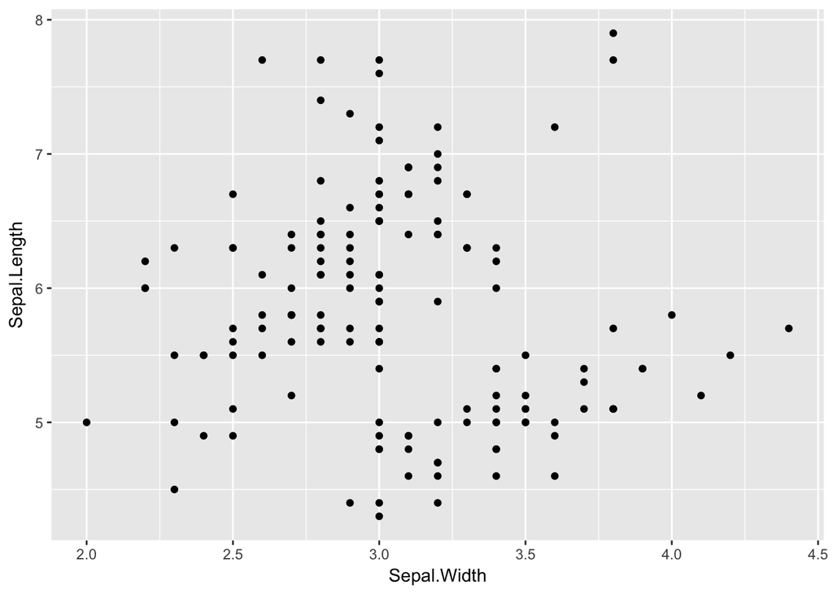

```r
ggplot(data = iris,
         aes (x = Sepal.Width, y = Sepal.Length)) + # data to plot
    geom_point () # scatter plot
```

We can use a simplified version of it

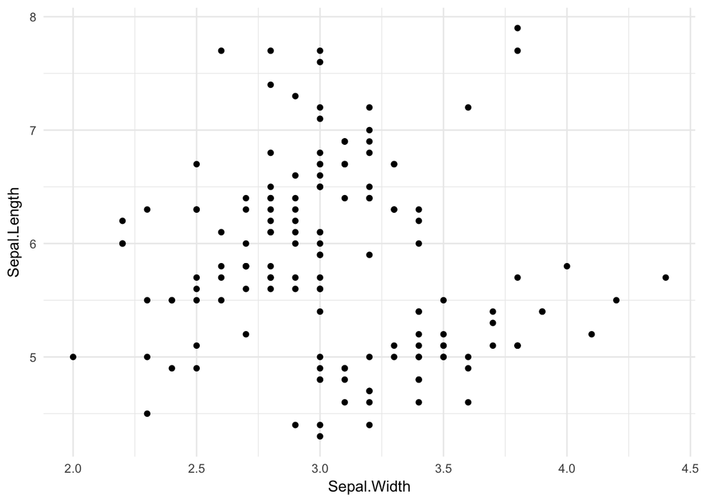

```r
ggplot (data = iris,
         aes (x = Sepal.Width, y = Sepal.Length)) +
    geom_point () +
  theme_minimal() #simplified version
```

We can get some fancy adding some colors by species, plot titles and axes names.

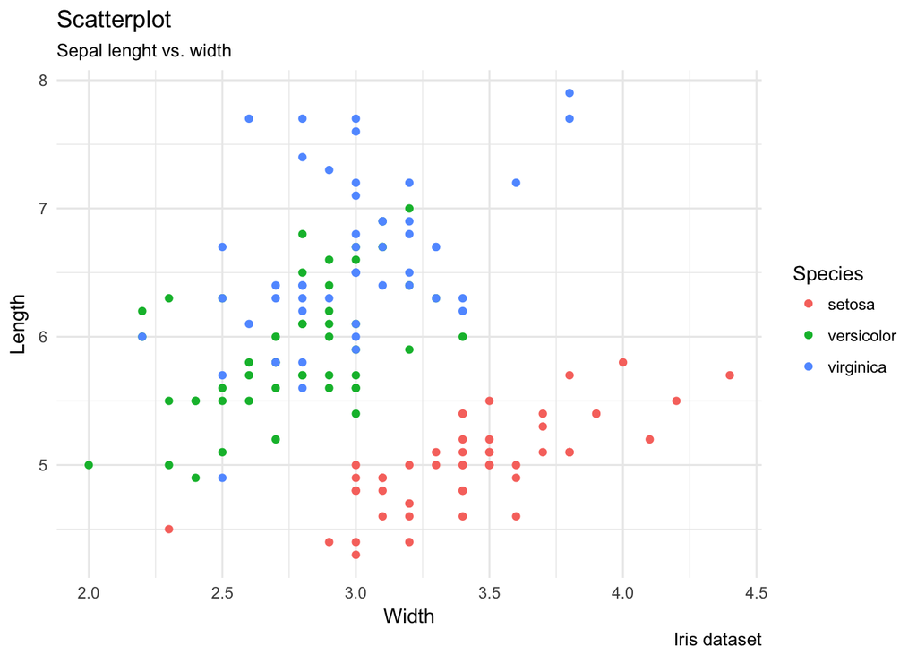

```r
ggplot (data = iris,
         aes (x = Sepal.Width, y = Sepal.Length,
              color = Species)) + # we add color by spp
  geom_point () +
  theme_minimal() +
  labs(subtitle = "Sepal lenght vs. width", # we add axes names and titles
       y = "Length",
       x = "Width",
       title = "Scatterplot",
       caption = "Iris dataset")
```

There seems to be a difference between species, lets try to plot a trend line to see

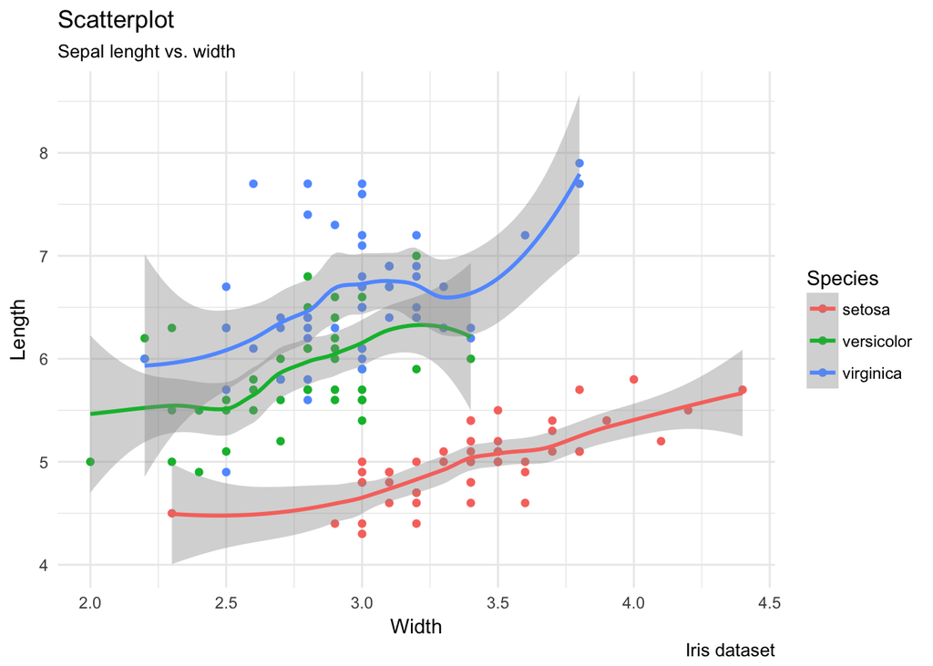

```r
ggplot (data = iris,
         aes (x = Sepal.Width, y = Sepal.Length, color=Species)) +
    geom_point (aes(col=Species)) +
  geom_smooth() + #add a trend line
  theme_minimal() +
  labs(subtitle="Sepal lenght vs. width",
       y = "Length",
       x = "Width",
       title = "Scatterplot",
       caption = "Iris dataset")
```

And I can even add more information into the plot by adding a dot size according to its sepal length

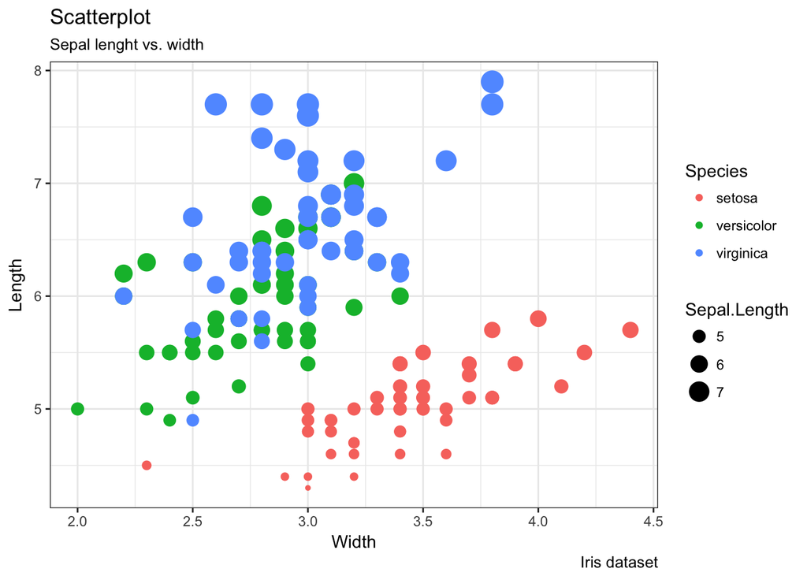

```r
ggplot(data = iris,
       aes (x = Sepal.Width, y = Sepal.Length)) +
  geom_point (aes(col = Species, size = Sepal.Length )) +
  theme_bw()  + # pre-set the bw theme.
  labs(subtitle = "Sepal lenght vs. width",
       y = "Length",
       x = "Width",
       title = "Scatterplot",
       caption = "Iris dataset")
```

There are many other fancy plots that you can do with ggplot2, [here](http://r-statistics.co/Top50-Ggplot2-Visualizations-MasterList-R-Code.html) there is a collection of them.